# SQL Showcase

2023-11-11

G. Gallagher

- Setup
  - Original Schema
- Cleaning Data
  - Replacing Missing Data
    - [UPDATE]
  - Protecting Sensitive Data
    - [ALTER | DROP]
    - [MASKING]
    - [CREATE USER | GRANT access]
  - Converting Datatypes
    - [DROP]
    - [CONSTRAINT]
  - Renaming Table
    - [EXEC]
- Creating Tables
  - Create Table
    - [PRIMARY & FOREIGN KEYS | INDEXING]
    - [COMPOSITE KEY | INDEXING]
  - Updated Schema
  - Populate New Tables
    - [INSERT INTO]
- Views
  - View - Outstanding Orders
    - [VIEW | LEFT JOIN]
  - View - Expired Batches
    - [VIEW | INNER JOIN]
- Functions
  - Function - Stock Check
    - [SCALAR FUNCTION]
  - Function - Batches Nearing Expiry
    - [TABLE FUNCTION | SUBQUERY]
  - Function - Sales Performance
    - [TABLE FUNCTION | CTE | CASE WHEN | GROUP BY | ORDER BY | LEFT JOIN | AGGREGATED FUNCTIONS]
- Procedures
  - Procedure - Purchase Received
    - [PROCEDURE | TRANSACTION | TRY CATCH | SUB-QUERY | LEFT JOIN]
  - Procedure - Restock Check
    - [PROCEDURE | TEMPORARY TABLE | TRANSACTION | TRY CATCH | IF | ALIASING | INNER & LEFT JOINS]
- Full Queries Documentation

# Setup

I used the “Northwind” sample enterprise resource planning (ERP) database provided [here](https://github.com/Microsoft/sql-server-samples/tree/master/samples/databases/northwind-pubs) by Microsoft to demonstrate an array of SQL concepts below; with the full set of queries found at the bottom.

## Original Schema

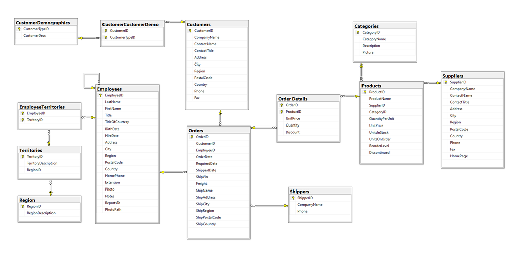

# Cleaning Data

## Replacing Missing Data

After previewing the data, this is a simple query in which the ‘Customers’ table is filtered for NULL values in the ‘PostalCode’ column, which is then replaced with the correct data.

### [UPDATE]

```sql
SELECT *
FROM Customers
WHERE PostalCode IS NULL

UPDATE Customers
SET PostalCode = 'T45 HE16'
WHERE CustomerID = 'HUNGO'
```

## Protecting Sensitive Data

The ‘Customers’ table also contains information such as ‘ContactName’, ‘Phone’ and ‘Fax’.

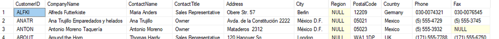

These are/may be personally identifiable information (PII) and thus should be protected. And while this can be done through the databases user access and roles;for the sake of this showcase I am going to add an extra layer of protection and masking the data as well.

Firstly, for the type of partial masking I want to apply it is necessary to split the ‘ContactName’ column into it’s first and last name components.

### [ALTER | DROP]

```sql
ALTER TABLE Customers
ADD  ContactFirstName nvarchar(20), ContactLastName nvarchar(20)

Update Customers
SET ContactFirstName = TRIM(SUBSTRING(ContactName, 1, CHARINDEX(' ', ContactName)))

Update Customers
SET ContactLastName = TRIM(SUBSTRING(ContactName, CHARINDEX(' ', ContactName), LEN(ContactName)))

ALTER TABLE Customers
DROP COLUMN ContactName
```

Then each of the columns containing sensitive data can be appropriately masked to partially obscure the information without completely redacting it.

### [MASKING]

```sql
ALTER TABLE Customers
ALTER COLUMN ContactFirstName ADD MASKED WITH (FUNCTION = 'partial(1, "****", 0)')

ALTER TABLE Customers
ALTER COLUMN Phone  ADD MASKED WITH (FUNCTION = 'partial(0, "####", 4)')

ALTER TABLE Customers
ALTER COLUMN Fax ADD MASKED WITH (FUNCTION = 'partial(0, "####", 4)')
```

We can then test this by creating a user account without admin privileges to see how effective the masks are.

### [CREATE USER | GRANT access]

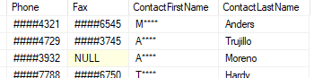

```sql
CREATE USER Tester WITHOUT LOGIN
GRANT SELECT ON SCHEMA::dbo to Tester

EXECUTE AS USER = 'Tester'
SELECT *
FROM Customers
```